# Homework #5

## A.1 [6 points] Expectations do not necessarily exist!

Unfortunately, the expected value of a random variable may not be defined. For example, if $\theta$ is an angle uniformly distributed in the interval $(-\pi/2,\pi/2)$, then $X=\alpha\tan(\theta)$ has the following distribution:

$$ f(x)=\frac{\alpha}{\pi}\frac{1}{x^2+\alpha^2} $$

Show that $E(X)$ is undefined (HINT: compute $E(X)$ using a u-substitution and show that the integral does not converge).

To find $E(X)$ note that, $$\begin{gather*} X = \alpha tan(\frac{\pi}{2}) = \infty \\ X = \alpha tan(-\frac{\pi}{2}) = -\infty \end{gather*} $$ which will be our bounds for $E(X)$ so, $$ \begin{gather*} \int^{\infty}_{-\infty} x \bigg[\frac{\alpha}{\pi} (\frac{1}{x^2 + \alpha^2})\bigg]dx \\ \frac{2\alpha}{\pi}\int^{\infty}_{-\infty} \frac{x}{x^2 + \alpha^2}dx \end{gather*} $$ Let $u = x^2 + \alpha^2$ therefore $du = 2x dx$. Hence:

$$\begin{gather*} \frac{\alpha}{\pi}\int^{\infty}_{-\infty} \frac{1}{u}du \\ \frac{\alpha}{\pi}\bigg[\ln{\big(x^2 + \alpha^2\big)}\bigg]^{\infty}_{-\infty} \\ \end{gather*}$$

So if we let $a \rightarrow \infty$ and $b \rightarrow \infty$ we can take the limit of, $$ \frac{\alpha}{\pi}\bigg[\ln{\big(x^2 + \alpha^2\big)}\bigg]^{a \rightarrow \infty}_{b \rightarrow -\infty} $$ Hence, $$ \begin{gather*} \lim_{a\rightarrow \infty} \ln(a^2 + \alpha^2) = \infty \\ \lim_{b\rightarrow -\infty} \ln(b^2 + \alpha^2) = \infty \end{gather*} $$ Ergo, $$\begin{gather*} \frac{\alpha}{\pi}\bigg[\ln{\big(x^2 + \alpha^2\big)}\bigg]^{a \rightarrow \infty}_{b \rightarrow -\infty} = \infty \end{gather*}$$

## A.2 Properties of expectation

Let $X$ be a random variable such that

- $E(X)=5$
- $sd(X)=2.5$

and let $Y$ be a random variable such that

- $E(Y)=8$,
- $sd(Y)=2$.

$X$ and $Y$ are not independent. In fact, $corr(X,Y)=0.8$.

**Compute the following.**

**A.2(a) [3 points] $E(4X+3Y+1)$**

$E(4X + 3Y + 1) = 4E(X) + 3E(Y) + 1 = 4(5) + 3(8) + 1 = 45$

**A.2(b) [6 points] $sd(4X+2Y+2)$**

**A.2(c) [4 points] $E(3X^2 + Y)$**

We know $sd(X) = \sqrt{(Var(X)}$. We also know $Var(X) = E(X^2) - [E(X)]^2$

Therefore $sd(X) = 2.5 = \sqrt{6.25}$, so $Var(X) = 6.25$. From above we now have: $$6.25 = E(X^2) - 25 \Rightarrow E(X^2) = 31.25$$

Ergo, $$E(3X^2 + Y) = 3E(X^2) + E(Y) = 3(31.25) + 8 = 101.75$$

**A.2(d) [4 points] $E(8XY)$**

We know that $Corr(X,Y) = \frac{Cov(X,Y)}{sd(X)sd(Y)}$ and $Cov(X,Y) = E(XY) - E(X)E(Y)$

We are given that $Corr(X,Y)=0.8$ therefore: $$0.8 = \frac{Cov(X,Y)}{sd(X)sd(Y)} \Rightarrow 0.8 = \frac{E(XY) - E(X)E(Y)}{sd(X)sd(Y)}$$

Now plug in, $$0.8 = \frac{E(XY) - 5(8)}{(2.5)2} \Rightarrow 0.8 = \frac{E(XY) - 40}{5} \newline \Rightarrow E(XY) = 352$$

## A.3 [4 points] Covariance and independence

**Suppose that X and Y are independent random variables. Prove that $E(XY) = E(X)E(Y)$.**

For a continuous r.v., $X$ and $Y$: $$E(XY) = E\big(g(x)h(y)\big) = \int^{\infty}_{-\infty}\int^{\infty}_{-\infty}g(x)h(y)f_x(x)f_y(y)dxdy \newline \Rightarrow \bigg(\int^{\infty}_{-\infty}g(x)f_x(x)dx\bigg)\bigg(\int^{\infty}_{-\infty}h(y)f_y(y)dy\bigg)\newline \Rightarrow E\big(g(x)\big)E\big(h(y)\big) \newline \Rightarrow E(X)E(Y)$$

For a discrete r.v., $X$ and $Y$: $$\begin{gather*} E(XY) = E\big(g(x)h(y)\big) \\ = \sum_x\sum_y g(x)h(y)P(X)P(Y) \\ = \bigg(\sum_x g(x)P(X)\bigg)\bigg(\sum_yh(y)P(Y)\bigg) \\ = E\big(g(x)\big)E\big(h(y)\big) \\ = E(X)E(Y) \end{gather*}$$

## A.4 Properties of $\bar{X}$

Let $ X_{1},X_{2},...,X_{n} \overset{iid}{\sim} N( \mu , \sigma^{2})$.

**A.4(a) [4 points] Show (without integration), that $sd(\bar{X}) = \frac{\sigma}{\sqrt{n}}$**

$$ \begin{gather*} Var(\bar{X}) = Var\bigg(\frac{1}{n}\sum^n_{i=1}X_i\bigg) \\ Var(\bar{X})= \frac{1}{n^2}Var\bigg(sum^n_{i=1} X_i \bigg) \\ Var(\bar{X}) = \frac{1}{n^2}\sum^n_{i=1} Var\big(X_i\big) \\ Var(\bar{X}) = \frac{1}{n^2}\cdot \sigma^2n \\ Var(\bar{X}) = \frac{\sigma^2}{n} \end{gather*} $$

And $sd(\bar{X}) = \sqrt{Var(\bar{X})}$: $$sd(\bar{X}) = \sqrt{Var(\bar{X})} = \sqrt{\frac{\sigma^2}{n}} = \frac{\sigma}{\sqrt{n}}$$

**A.4(b) [5 points] Show that $\displaystyle\bar{X} = \mu + \frac{\sigma}{\sqrt{n}}Z$ where $Z \sim N(0,1)$.**

We know $Z\sim N(0,1)$ which also mean that $Z = \frac{\bar{X} - \mu}{sd(\bar{X})}$ so: $$\begin{gather*} Z = \frac{\bar{X} - \mu}{sd(\bar{X})} \\ Z = \frac{\bar{X} - \mu}{\frac{\sigma}{\sqrt{n}}} \\ {\frac{\sigma}{\sqrt{n}}}Z = \bar{X} - \mu \\ \bar{X} = \mu + {\frac{\sigma}{\sqrt{n}}}Z \end{gather*}$$

**A.4.(c) [7 points] Use A.4(b) to find $\displaystyle Var(\bar{X}^{2})$. Assume that $Cov(Z, Z^2) = 0$ (it's true, but you don't have to prove it!).**

$$ \begin{gather*} \bar{X}^2 = \big(\mu + \frac{\sigma}{\sqrt{n}}\cdot Z\big)^2 \\ \bar{X}^2 = \mu^2 + \frac{2\mu\sigma}{\sqrt{n}}\cdot Z + \frac{\sigma^2}{n}\cdot Z^2 \end{gather*}$$

Taking $Var(\bar{X}^2)$: $$ \begin{gather*} Var(\bar{X}^2) = Var\bigg(\mu^2 + \frac{2\mu\sigma}{\sqrt{n}}\cdot Z + \frac{\sigma^2}{n}\cdot Z^2\bigg) \\ = \bigg(2\frac{\mu\sigma}{\sqrt{n}}\bigg)^2\cdot Var(Z) + \bigg(\frac{\sigma^2}{n}\bigg)^2 \cdot Var(Z^2) + 2\cdot\frac{1}{2}\cdot\frac{1}{2}\cdot Cov(Z,Z^2) \\ = \frac{4\mu^2\sigma^2}{n} + \frac{2\sigma^4}{n^2} \end{gather*}$$

## A.5 Let's go bowling

Franklin and Sue Ellen are bowling pals. They have different skill levels. In particular,

- Franklin’s scores are normally distributed with a mean of $\mu_{F} = 110$ and a variance of $\sigma_{F}^{2} = 75$
- Sue Ellen’s scores are normally distributed with a mean of $\mu_{S} = 140$ and a variance of $ \sigma_{S}^{2} = 60$

Let $X_{F}$ be the random variable that denotes Franklin’s score, and $X_{S}$ the random variable that denotes Sue Ellen’s score. Answer the questions below.

**A.5(a) [6 points] What is the distribution of $\bar{X}$ , the average of the two bowling scores? (Name the distribution and specify any parameters of the distribution.)**

$X_f$ and $X_s$ are note iid so to find our average we know, $$\begin{gather*} \bar{X} = \frac{1}{2}\sum^2_{i=1} X_i \\ E(\bar{X}) = \frac{1}{2}\sum^2_{i=1} E(X_i) \\ = \frac{1}{2}\big[E(X_f) + E(X_s)\big] \\ = \frac{1}{2}\big[110 + 140\big] \\ E(\bar{X}) = 125 \end{gather*}$$

Similarly for $Var(\bar{X}$: $$\begin{gather*} Var(\bar{X}) = \bigg(\frac{1}{2}\bigg)^2\cdot Var(X_f + X_s) \\ = \bigg(\frac{1}{2}\bigg)^2\big[Var(X_f + X_s)\big] + 2\cdot\bigg(\frac{1}{2}\bigg)^2\cdot Cov(X_f, X_s) \\ = \frac{\sigma^2_f + \sigma^2_s}{4} + \frac{1}{2}\big(Cov(X_f, X_s)\big) \end{gather*} $$

The distribution is still normal, the shape doesn't change. The variable that changes is the mean.

**A.5(b) [3 points] Based on the information you have at this point, can we say that $Var(\bar{X})=\frac{\sigma_{F}^{2}+\sigma_{S}^{2}}{4}$? Justify your answer.**

From the information given we cannot say that $Var(\bar{X})=\frac{\sigma_{F}^{2}+\sigma_{S}^{2}}{4}$ becuase we are not certain that $X_f$ and $X_s$ are independent. If so, then yes - $Var(\bar{X})=\frac{\sigma_{F}^{2}+\sigma_{S}^{2}}{4}$. However, we cannot conclude to that yet.

**A.5(c) [5 points] Assume that Franklin’s and Sue Ellen’s scores are independent. What is the probability that the sample average score of the group will be between 120 and 140 points?**

$$\begin{gather*} P(120 \leq Z \leq 140) \\ = P(\frac{120 - 125}{\sqrt{33.75}}\leq Z \leq \frac{140 - 125}{\sqrt{33.75}}) \\ = P(-0.86 \leq Z \leq 2.58) \\ = P(Z \leq 2.58) - P(Z \leq -0.86) \\ \approx 0.8003 \end{gather*} $$

**A.5(d) [5 points] Assume that Franklin’s and Sue Ellen’s scores are independent. What is the probability that both players bowl a score less than 135?**

We are looking for $P(X_f \leq 135) \cdot P(X_s \leq 135)$, so: $$ \begin{gather*} P\bigg(Z \leq \frac{135 - 110}{\sqrt{75}}\bigg) = P(Z \leq 2.886) \approx 0.9989 \\ P\bigg(Z \leq \frac{135 - 140}{\sqrt{60}}\bigg) = P(Z \leq -0.64) \approx 0.259 \\ \therefore \\ P(Z \leq 2.886)\cdot P(Z \leq -0.64) \approx 0.2587 \end{gather*} $$

## B. Computational Problems

## B.1

Let $ X_{1},X_{2},...,X_{500} \overset{iid}{\sim} N( \mu = 5 , \sigma^{2} = 4)$.

**B.1(a) [7 points] Construct a matrix `x` with $m = 10,000$ columns, where each column is a different sample (i.e., set of realizations) from $ X_{1},X_{2},...,X_{500}$. Then, use `colMeans()` to find the mean of each sample/column. Store these means in `xbar`. Based on lecture, what is the distribution of `xbar`? Is a histogram of `xbar` consistent with that?**

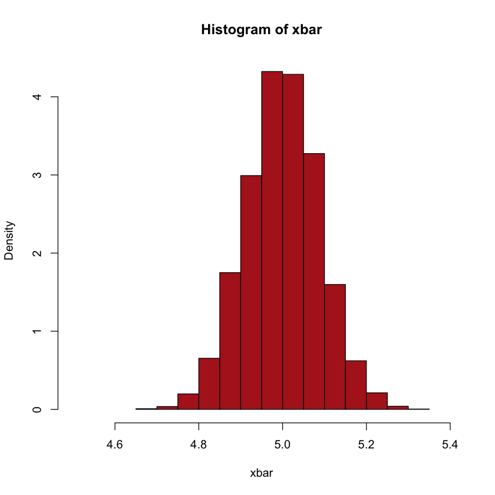

```r
m = 10000; n = 500;
x = replicate(m, rnorm(n,5,2));
xbar = colMeans(x);
hist(xbar, freq = FALSE, xlim=c(4.5, 5.4), col='firebrick')
```

Its a normal distribution and that $\bar{X}$ is the estimator of population paremeter, $\mu$.

```r
#Part A
cat('sd(X)', sd(xbar), '\n')
cat('A4-a', 2/sqrt(n), '\n')

#Part B
cat('mean of xbar', mean(xbar), '\n')
x_bar = 5 + 2/sqrt(n)*rnorm(n, 0,1)
cat('A4-b ',mean(x_bar), '\n')

#Part C
xbar2 = xbar^2
cat('variance of xbar', var(xbar^2), '\n')
var_x = (4*25*4)/n + (2*4^2)/n^2
cat('A4-c', var_x, '\n')
```

```
sd(X) 0.09088714
A4-a 0.08944272
mean of xbar 4.999152
A4-b  5.004506
variance of xbar 0.8258451
A4-c 0.800128
```

To make $\bar{X}$ closer we can increase the number of repitions of sample we generate.

## B. 2

**B.2(a) [4 points] Generate three random vectors of length $n = 500$ from:**

1. $X \sim beta(3,1)$
2. $Y \sim beta(3,1)$
3. $Z \sim beta(2,3)$

**Present numerical (using `cor()`) and visual evidence that $X$ and $Y$ are (effectively) uncorrelated.**

0.00990240095217502

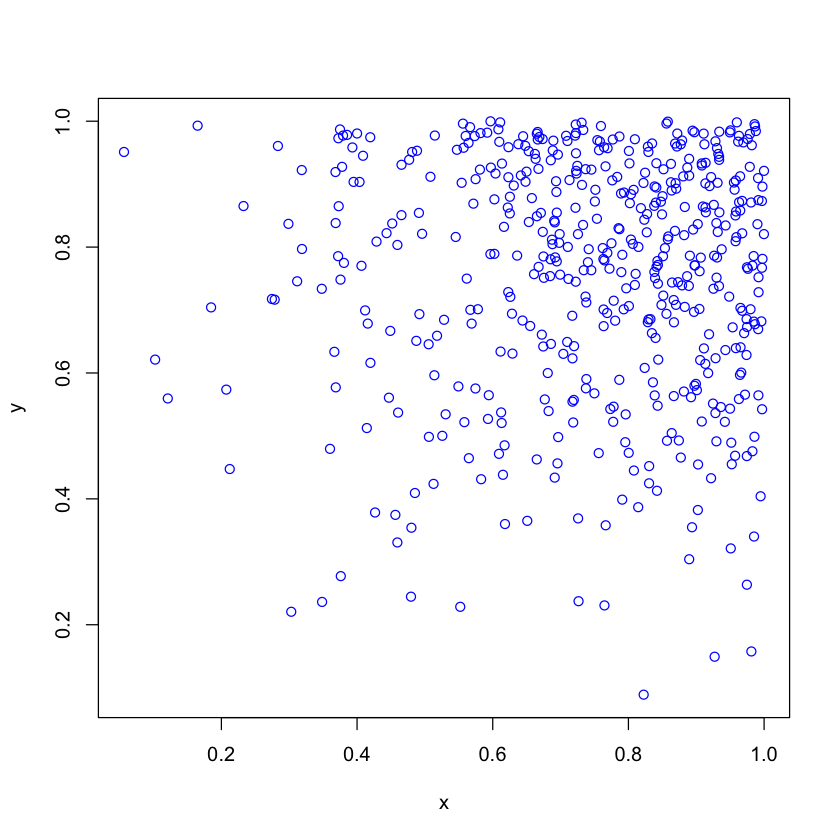

```r
n = 500;
x = rbeta(n, 3, 1)
y = rbeta(n, 3, 1)
z = rbeta(n, 2, 3)
cor(x, y)
plot(x,y, col = 'blue')
```

**B.2(b) [4 points] Create vectors `xstar` and `ystar` by taking `x` and `y` and dividing by `z`. Are `xstar` and `ystar` correlated? Support your claim with numerical and graphical evidence.**

0.886013518665739

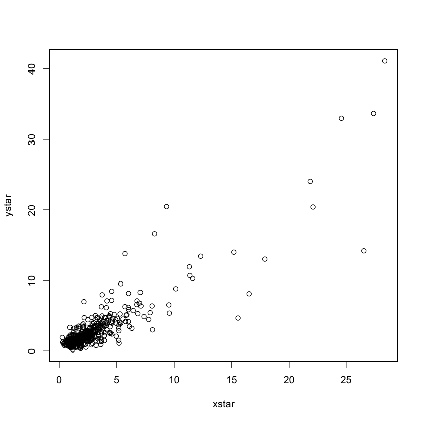

```r
xstar = x/z
ystar = y/z
cor(xstar, ystar)
plot(xstar, ystar)
```

Yes, I believe they are correlated because `ystar` grows position as `xstar` grows positive and the correlation value is a positive value.

**B.2(c) [4 points] Store these vectors in a data frame called `df`. Load the `ggplot2` library, and use the `ggplot() + geom_point()` function below to create a scatter plot of `xstar` and `ystar`, and color each point relative to the value of `z`.**

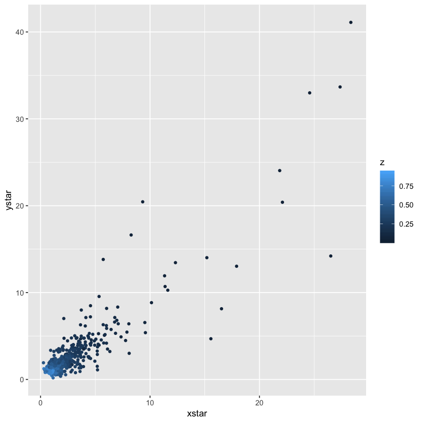

```r
library(ggplot2)
df = data.frame(xstar, ystar)
ggplot(df, mapping = aes(x = xstar, y = ystar)) + geom_point(aes(colour = z), shape = 16)
```

#### (d) [4 points] Interpret and analyze the results from the previous part. What practical lessons can you learn from this example?

Many of the points to the bottom left of the graph are more relative to the values of $z$ becuase the `z` value is getting closer to 1 - the division of `z` is more prominent. The points the top right of the graph do not relate to $z$ very much because `z` divides `xstar` and `ystar` very small. Additionally we can see as `xstar` increase `ystar` increase to and the relativity to `z` decreases.

## B.3 The central limit theorem revisited

The code `rf(n, 2, 3)` can be used to generate $n$ random numbers from an ["f-distribution"](https://en.wikipedia.org/wiki/F-distribution) with parameters `2` and `3` (don't worry to much about what the f-distribution is or models at this point; it's just a probability distribution!).

**B.3(a) [5 points] Construct a matrix `x` with $m = 10,000$ columns, where each column is a different sample of size $n = 25$ from the f-distribution with parameters `2` and `3`. Construct a histogram of one of the columns. What can you say about the shape of this distribution?**

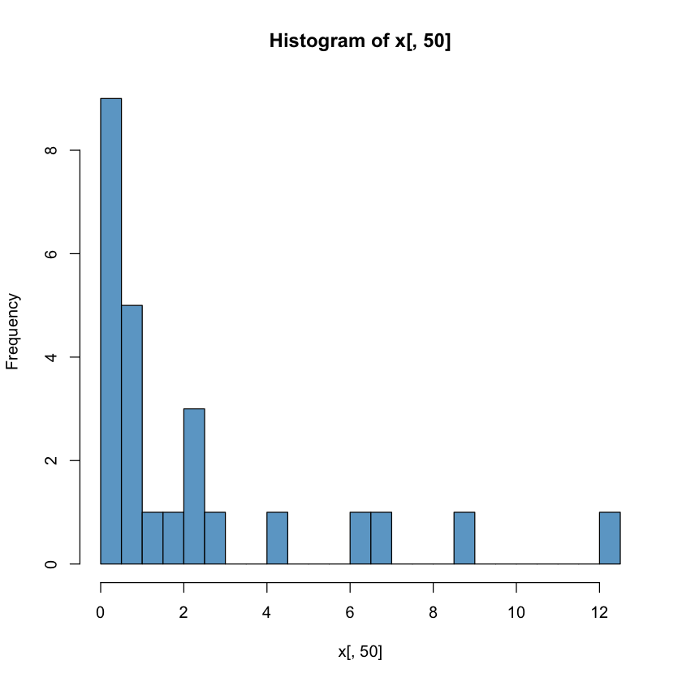

```r
set.seed(50)
n = 25; m = 10000;
x = replicate(m, rf(n, 2,3))
hist(x[,50], col = 'skyblue3', breaks = 20)
```

This distribution looks approximately simlar to a right skewed distribution or a mulitplicative inverese graph or a hyberpola. All the value are on one side of the histgram and quicly decrease as the value in the x axes increases.

**B.3(b) [5 points] Use `colMeans()` to find the mean of each sample (each column of `x`). Store these means in `xbar`. Construct a histogram of `xbar`. Does the histogram look normal (or approximately normal)? If yes, why? If no, why not?**

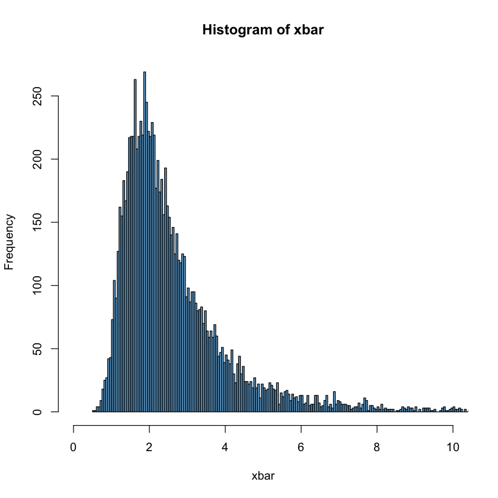

```r
xbar = colMeans(x)
hist(xbar, col = 'skyblue3', breaks = 10000, xlim = c(0,10))
```